# ДР 10_7

Что нужно сделать Визуализация данных — полезный инструмент не только для аналитика, но и для заказчика. Поэтому в этом задании вы построите визуализации, которые помогут сформулировать дальнейшие гипотезы, а также продемонстрировать заказчику результаты вашего анализа.

ЗАДАЧА 1) Воспользуйтесь таблицей с фродовыми данными, которую вы сохранили в одном из предыдущих модулей. Постройте гистограмму распределения количества этапов воронки, которые были скомпрометированы. Попробуйте объяснить, руководствуясь здравым смыслом, почему именно эти этапы оказались легко атакованы.

ЗАДАЧА 2) Постройте воронки продаж по всем каналам коммуникации с клиентом. Сделайте предварительные выводы, какой канал коммуникации кажется вам менее перспективным.

ЗАДАЧА 3)Постройте графики затрат для каждого рекламного канала и прибыли по ним на последнем этапе воронки. Подумайте, как удачнее расположить получившиеся графики.

ЗАДАЧА4) Постройте график распределения операционной системы пользователя для каждого канала коммуникации. Какие выводы можно сделать?

Что оценивается Корректность подбора и построения графиков для каждого типа метрик. Оформление визуализаций. Корректность выводов.

Как отправить работу на проверку Итоговый файл должен быть в виде ноутбука, сохранённого в формате HTML, с выводом всех ячеек и комментариями после них.

```python
# подгружаем нужные библиотеки
import pandas as pd
import numpy as np
import matplotlib.pyplot as plt
import seaborn as sns
```

```python
my_df = pd.read_csv('marketing_dataset_m8.tsv', sep='\t')
my_df.drop(columns=['source', 'time_spent']).groupby(['watch', 'click', 'take']).count()
```

| watch | click | take | ID |
| --- | --- | --- | --- |
| 1 | 0 | 0 | 8891 |
|  | 1 | 0 | 10297 |
|  |  | 1 | 814 |

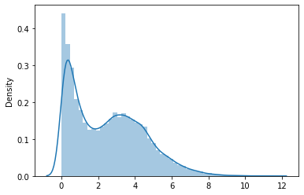

```python
sns.distplot(my_df.time_spent.values)
```

На графике времени проведенной на страничке видно два максимума, что может свидетельствовать о некорректоности данных

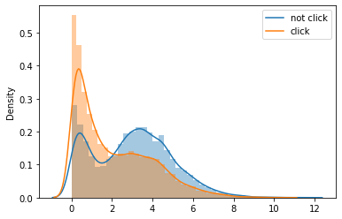

```python
sns.distplot(my_df[my_df.click==0].time_spent.values)
sns.distplot(my_df[my_df.click==1].time_spent.values)
plt.legend(['not click', 'click'])
```

Причем, для клиентов, кто кликнул и не кликнул ситуация разительно отличается

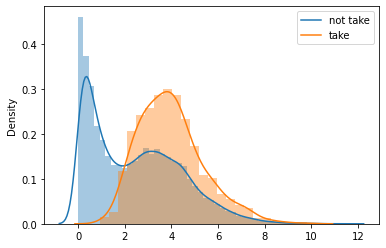

```python
sns.distplot(my_df[my_df['take']==0].time_spent.values)
sns.distplot(my_df[my_df['take']==1].time_spent.values)
plt.legend(['not take', 'take'])
```

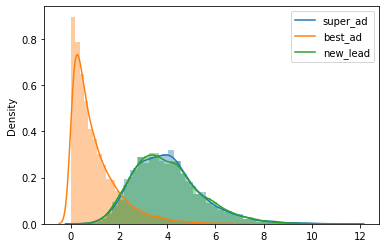

```python
sns.distplot(my_df[my_df.source=='super_ad'].time_spent.values)
sns.distplot(my_df[my_df.source=='best_ad'].time_spent.values)
sns.distplot(my_df[my_df.source=='new_lead'].time_spent.values)
plt.legend(['super_ad', 'best_ad', 'new_lead'])
```

Причем, для кликов по рекламе от best_ad и кликов от двух других рекламных агенств (new_lead, super_ad), поведение пользователей разительно отличается